# Investigando dados do Titanic

- Dataset [https://www.udacity.com/api/nodes/5420148578/supplemental_media/titanic-datacsv/download]
- Data description [https://www.kaggle.com/c/titanic/data]

## 1) Introdução

Como vimos no filme dirigido por James Cameron que narra o acidente do navio Titanic, mulheres e crianças são prioridade em um resgate. Nesse contexto, esse estudo tem como objetivo analisar os dados dos passageiros e verificar a correlação entre gênero, idade e sobrevivência. Adicionalmente, a correlação entre poder aquisitivo do passageiro e sua sobrevivência também será analisada. Essa informação será inferida a partir do dado se o bilhete comprado foi para uma cabine de primeira, segunda ou terceira classe.

As questões que serão respondidas:

- Idade e gênero influenciaram a sobrevivência dos passageiros?
- A classe a qual eles pertenciam teve alguma influência?

## 2) Variáveis

- **Dependente:** Sobrevivência do Passageiro
- **Independente:** Gênero, idade e classe da cabine

## 3) Análise

### 3.1) Conhecendo os dados

```python
import numpy as np
import pandas as pd
import matplotlib.pyplot as plt
import seaborn as sns
import math


%matplotlib inline

titanic_file = 'titanic_data.csv'
titanic_data = pd.read_csv(titanic_file)

titanic_data.head()
```

|  | PassengerId | Survived | Pclass | Name | Sex | Age | SibSp | Parch | Ticket | Fare | Cabin | Embarked |
| --- | --- | --- | --- | --- | --- | --- | --- | --- | --- | --- | --- | --- |
| 0 | 1 | 0 | 3 | Braund, Mr. Owen Harris | male | 22.0 | 1 | 0 | A/5 21171 | 7.2500 | NaN | S |
| 1 | 2 | 1 | 1 | Cumings, Mrs. John Bradley (Florence Briggs Th... | female | 38.0 | 1 | 0 | PC 17599 | 71.2833 | C85 | C |
| 2 | 3 | 1 | 3 | Heikkinen, Miss. Laina | female | 26.0 | 0 | 0 | STON/O2. 3101282 | 7.9250 | NaN | S |
| 3 | 4 | 1 | 1 | Futrelle, Mrs. Jacques Heath (Lily May Peel) | female | 35.0 | 1 | 0 | 113803 | 53.1000 | C123 | S |
| 4 | 5 | 0 | 3 | Allen, Mr. William Henry | male | 35.0 | 0 | 0 | 373450 | 8.0500 | NaN | S |

#### 3.1.1) Passageiros por gênero

```
Total de passageiros: 891
Sex
female    314
male      577
dtype: int64
```

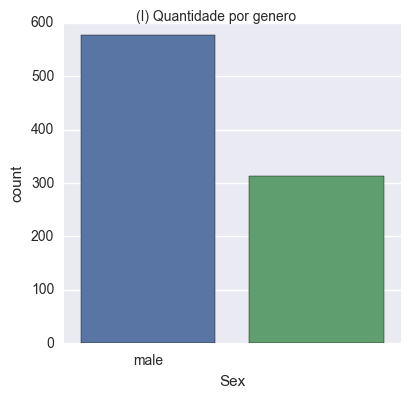

```python
print "Total de passageiros:", titanic_data['PassengerId'].count()
print titanic_data.groupby("Sex").size()

c = sns.factorplot(x="Sex", data=titanic_data, kind="count")
c.fig.suptitle("(I) Quantidade por genero")
c.set_xticklabels(step=2)
```

#### 3.1.2) Histograma de idades

```
Idade media:  29.6991176471
Desvio padrao:  14.5264973323
```

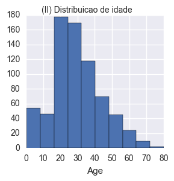

```python
print "Idade media: ", titanic_data['Age'].mean()
print "Desvio padrao: ", titanic_data['Age'].std()

h = sns.FacetGrid(titanic_data, margin_titles=True)
h.fig.suptitle("(II) Distribuicao de idade")
h.map(plt.hist, "Age", bins=10)
```

#### 3.1.3) Passageiros agrupados por classe da cabine

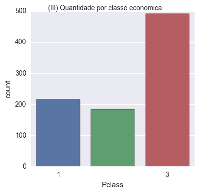

```python
b = sns.factorplot(x="Pclass", data=titanic_data, kind="count")
b.fig.suptitle("(III) Quantidade por classe economica")
b.set_xticklabels(step=2)
```

### 3.2) Preparação dos dados

#### 3.2.1) Checagem

Foi utilizado esse método para verificar se está tudo OK com os dados. Essa checagem é feita nas variáveis Age, Pclass e Sex procurando se há registros inválidos (ex: sexo diferente de 'male' e 'female', classe diferente de 1,2 ou 3, idades negativas, etc)

Se os registros estiverem OK, será retornado True. Se alguma falha for encontrada será retornado Falso e o valor do registro onde o problema foi encontrado.

Ao final um teste é realizado e será impresso True caso esteja tudo OK e False caso não.

```python
def is_data_ok(data):
    """
    From Titanic's test data, verify if chosen variables (Age, Pclass, Sex) show any problem like missing or suspicious data.
    Return: True if everything is OK, False if found any problem and the respective value
    """
    if data['Pclass'] not in (1,2,3):
        print "Invalid Pclass ",data['Pclass']
        return False
    if data['Sex'] not in ['male','female']:
        print "Invalid Sex ",data['Sex']
        return False
    if math.isnan(data['Age']) or data['Age'] < 0 or data['Age'] > 120:
        print "Invalid Age ",data['Age']
        return False
    return True
```

```python
# Testing if everything looks fine

result = titanic_data.apply(is_data_ok,axis=1)

print result.all() # Prints True if everything is OK
```

[output not shown]

[output cut: 123 more lines]

[output not shown]

#### 3.2.2) Preenchendo idades faltantes

Como podemos verificar anteriormente, entre as variáveis que utilizamos em nossa análise, existem valores faltantes em Age.

Para preencher esses valores, vamos agrupar os registros por Sex e Pclass e preenchê-los com a média para o grupo e classe.

Ex: Quando encontrado uma idade faltante, preenche esse valor com a média de idade do grupo e classe a qual o passageiro pertence.

Finalmente reexecutamos o mesmo teste realizado anteriormente e verificamos o valor True ou False.

```python
# Grouping missing ages by Pclass and sex
mean_ages =  titanic_data.groupby(['Sex','Pclass'])['Age'].mean()

print mean_ages
```

```
Sex     Pclass
female  1         34.611765
        2         28.722973
        3         21.750000
male    1         41.281386
        2         30.740707
        3         26.507589
Name: Age, dtype: float64
```

```python
def fill_missing_ages(register):
    """
    When it found a missing age, use his Pclass and Sex to fill this age with the mean of the group.
    Return: mean of the group if age is missing; or the age found.
    """
    global mean_ages
    if math.isnan(register['Age']):
        return mean_ages[register['Sex']][register['Pclass']]
    return register['Age']

titanic_data['Age'] = titanic_data.apply(fill_missing_ages, axis=1)
```

```python
# Exec the same test as before - should return True if everything is OK
result = titanic_data.apply(is_data_ok,axis=1)
print (result.all())
```

```
True
```

### 3.3) Classificação dos dados

Será criado um grupo chamado GAclass (gender/age class) que classifica o passageiro como sendo (1) adulto do sexo masculino, (2) adulto do sexo feminino e (3) criança independente do sexo.

```python
def classify(register):
    """
    Passengers were classified according their age/gender as: woman, man or children.
        man: sex = "male" and age > 15
        woman: sex = "female" and age > 15
        children: age <=15

    Parameter: a register with at less Age and Sex
    Return 1 if man, 2 if woman, 3 if children
    """

    if register['Sex'] == 'male' and register['Age'] > 15:
        return 1
    if register['Sex'] == 'female' and register['Age'] > 15:
        return 2
    return 3

titanic_data['GAclass'] = titanic_data.apply(classify, axis=1)

titanic_data.head()
```

|  | PassengerId | Survived | Pclass | Name | Sex | Age | SibSp | Parch | Ticket | Fare | Cabin | Embarked | GAclass |
| --- | --- | --- | --- | --- | --- | --- | --- | --- | --- | --- | --- | --- | --- |
| 0 | 1 | 0 | 3 | Braund, Mr. Owen Harris | male | 22.0 | 1 | 0 | A/5 21171 | 7.2500 | NaN | S | 1 |
| 1 | 2 | 1 | 1 | Cumings, Mrs. John Bradley (Florence Briggs Th... | female | 38.0 | 1 | 0 | PC 17599 | 71.2833 | C85 | C | 2 |
| 2 | 3 | 1 | 3 | Heikkinen, Miss. Laina | female | 26.0 | 0 | 0 | STON/O2. 3101282 | 7.9250 | NaN | S | 2 |
| 3 | 4 | 1 | 1 | Futrelle, Mrs. Jacques Heath (Lily May Peel) | female | 35.0 | 1 | 0 | 113803 | 53.1000 | C123 | S | 2 |
| 4 | 5 | 0 | 3 | Allen, Mr. William Henry | male | 35.0 | 0 | 0 | 373450 | 8.0500 | NaN | S | 1 |

### 3.4) Calculando correlações

Usando o método de correlação Pearson R implementado pela biblioteca Pandas, podemos verificar a correlação entre as variáveis.

```python
correlation = titanic_data.corr()

print "Coerrelação entre age/gender(GAclass) e sobrevivência: ",correlation['Survived']['GAclass']
print "Correlação entre classe da cabine (Pclass) e sobrevivência: ",correlation['Survived']['Pclass']
```

```
Coerrelação entre age/gender(GAclass) e sobrevivência:  0.472636807651
Correlação entre classe da cabine (Pclass) e sobrevivência:  -0.338481035961
```

```
Pclass  GAclass
1       1          0.352941
        2          0.978022
        3          0.833333
2       1          0.080808
        2          0.909091
        3          1.000000
3       1          0.119122
        2          0.491228
        3          0.431034
Name: Survived, dtype: float64
```

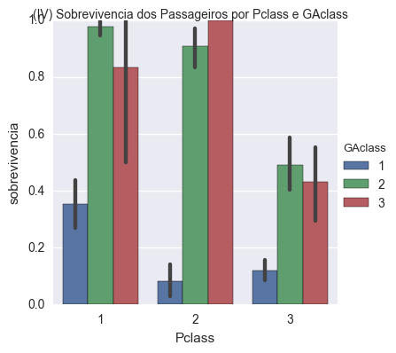

```python
# Gráfico de barras comparando o grupo GAclass e classe Pclass
p = sns.factorplot(x="Pclass", y="Survived", hue="GAclass", data=titanic_data,kind="bar")
p.fig.suptitle("(IV) Sobrevivencia dos Passageiros por Pclass e GAclass")
p.set_ylabels("sobrevivencia")

# Agrupando dados de sobrevivência por classe e grupo
survival_mean = titanic_data.groupby(["Pclass","GAclass"])["Survived"].mean()
print survival_mean
```

### 4) Conclusão

Comparando os gráficos I e IV, vemos que mesmo havendo maior número de homens no navio, um número muito superior de mulheres sobreviveu. Também há disparidade entre sobrevivência entre classes das cabines, onde vemos um número maior de passageiros na terceira classe e menor número de sobreviventes comparando os gráficos III e IV.

Finalmente, o gráfico IV nos mostra que a quantidade de sobreviventes dos grupos mulheres e crianças para as três classes foi expressivamente maior. Na média os passageiros de primeira classe sobreviveram mais que os da segunda, e estes mais que os da terceira, mostrando também uma correlação entre poder econômico e sobrevivência. Como destaques, vemos que: (i) os passageiros homens (grupo com menor número de sobreviventes) da primeira classe (0.35) sobreviveram mais do que a soma de de sobreviventes do mesmo grupo nas classes inferiores (0.08 + 0.12 = 0.20); e (ii) apenas na 2ª classe houve maior média de sobrevivência das crianças (1.00 contra 0.90) , enquanto nas outras as mulheres tiveram maior número (0.98 contra 0.83 na primeira classe e 0.49 contra 0.43 na terceira).

É importante ressaltar que essas são apenas análises iniciais observadas a partir dos dados disponíveis. E tais correlações não implicam necessariamente uma causalidade para os fatos. Para tal é necessário a realização de mais testes.

### 5) Leituras

- MatplotLib [http://matplotlib.org/users/pyplot_tutorial.html]
- Data Visualization in Python: Advanced Functionality in Seaborn [http://blog.insightdatalabs.com/advanced-functionality-in-seaborn/]
- Pandas.Dataframe.corr [http://pandas.pydata.org/pandas-docs/stable/generated/pandas.DataFrame.corr.html]
- Seaboorn Examples [http://seaborn.pydata.org/examples/index.html]